# GLM extensions exercise

Ben Bolker

23:02 28 June 2015

# Preliminaries

Loading packages:

```r
library("emdbook")  ## for reedfrog data
library("aods3")    ## for overdispersion tests
library("bbmle")    ## for GNLMs and AICtab
library("mgcv")     ## for GAMs
library("pscl")     ## for zero-inflated models
library("MASS")     ## for glm.nb; built in
```

`glmmADMB` is not on CRAN:

```r
if (!require("glmmADMB")) {
    install.packages("R2admb") ## install dependency first
    install.packages("glmmADMB",
                     repos="http://www.math.mcmaster.ca/bolker/R",
                     type="source")
    }
```

# Location models: fitting functional responses

Functional responses are a particularly simple example of nonlinear curves. Since functional response experiments usually measure the number of prey killed out of a starting total, they are naturally modeled as binomial. I’m going to use James Vonesh’s data set on *Hyperolius spinigularis*, which is included with the `emdbook` package:

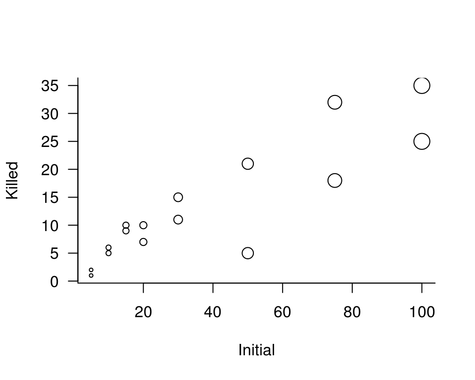

```r
par(las=1,bty="l")  ## cosmetic
plot(Killed~Initial,data=ReedfrogFuncresp,
     cex=sqrt(Initial*0.05)) ## make point area proportional to N
```

```r
## 'Rfd' is shorter/easier to type, and proportion variable will be handy
Rfd <- transform(ReedfrogFuncresp,
                 prop=Killed/Initial)
## or Rfd <- ReedfrogFuncresp; Rfd$prop <- Rfd$Killed/Rfd$Initial
```

- Fit a linear model:

```r
summary(lm(Killed~Initial,data=Rfd))
```

*Inspect the summary. Use `abline()` to add the regression line to the plot above. What do the coefficients, $p$-value, etc., mean? What do you think you could take away from this analysis?*

- Fit a naive GLM:

```r
glm1 <- glm(prop~Initial,weights=Initial,data=Rfd,family=binomial)
## I recommend prop~. + weights syntax for binomial GLMs instead of
## cbind(Killed,Initial-Killed) ~ ...
summary(glm1)
```

*What do the parameters and p-values of this model mean? Check overdispersion by computing `deviance(.)/df.residual(.)`, or with `gof()` (`aods3` package) and adjust accordingly (I would recommend `family=quasibinomial` as the simplest solution in this case; note that the parameter estimates will not change.) Compare the results.*

Construct a new data frame with evenly spaced initial numbers for prediction purposes:

```r
pframe <- data.frame(Initial=min(Rfd$Initial):max(Rfd$Initial))
```

*Now use `predict()` to get the predicted values for these initial densities (don’t forget to use `type="response"` to get probabilities rather than log-odds values). Plot the* proportions* (not numbers) killed (response) vs `Initial` (predictor) and use `lines()` to superimpose your predictions on the plot.*

You may be surprised at the linearity of the predicted curve. What happened? Did we mess something up? If you don’t understand right away and want to gain more insight, or if you think you understand and want to check yourself, try redoing the predictions with a wider range of initial densities (up to 1000) and re-do the plot with wider limits (`xlim=c(1,1000)`, `ylim=c(0,0.7)`) …

If you already know how to use `ggplot`, you can try plotting the data and adding

```r
geom_smooth(method="glm",family="quasibinomial",
            aes(weight=Initial),fullrange=TRUE)+
    expand_limits(x=0,y=1000)
```

to replicate the plot we’ve just done. (If you don’t use `ggplot`, this will seem completely mysterious. Sorry. Try not to let it bother you.)

- Now let’s try fitting a nonlinear model. The underlying model of a Holling type II functional response model is $\begin{split} K & \sim \text{Binom}(p_d,N) \\ p_d & = a/(1+ahN) \end{split}$ where $a$ is the attack rate, $N$ is the initial density (which is assumed not to change much over the course of the epidemic), $p_d$ is the *per capita* probability of predation (the expected number killed is $p_d N$). In order to have a chance of getting this to work we also have to have reasonable guesses for the initial parameters. If we do the algebra we can work out that the asymptote of the killed ($K$) vs initial ($N$) graph is $1/h$ and the initial slope is $a$. (*If you’re not frightened of algebra, stop and work this out yourself.*) Eyeballing the graph, it seems as though the asymptote might be around 50 and the initial slope might be around 1/4 …

```r
mle1 <- mle2(Killed~dbinom(prob=a/(1+a*h*Initial),
                           size=Initial),
             data=Rfd,
             start=list(a=1/4,h=1/50))
```

This gives us reasonable answers (but also warnings, which we could probably get rid of by using a bounded optimizer (`method="L-BFGS-B"`, `lower=c(0,0)`) or by fitting $a$ and $h$ on the log scale (`prob=exp(loga)/(1+exp(loga)*exp(logh)*Initial)`)). Compute the predicted probabilities (by hand or using `predict()`) and overlay them on the previous graphs. How big a difference does it make? * Now we’ll try to fit the same model with an inverse-link GLM.

```r
glm_inv <- glm(prop~Initial,
    weights=Initial,
    family=quasibinomial(link="inverse"),
    data=Rfd)
```

Check that the parameters are equivalent. Superimpose the predictions on plot(s).

- We could also fit a GAM:

```r
gam1 <- gam(prop~s(Initial,k=8),
            weights=Initial,
            family=quasibinomial,data=Rfd)
```

- Rogers random-predator model: see Bolker 2008, `?lambertW` in the `emdbook` package. How much difference does it make? How do the interpretations of the parameters change?

# Zero-inflated models

Data from Roulin and Bersier (2007) on owlet begging behaviour (our main observation will be on how many “sibling negotiation” events there were – number of calls recorded within 15 minutes of parental arrival on the nest). There are in fact multiple observations per nest (meaning that we ought to be using a zero-inflated GLMM), but we’re going to ignore that for now.

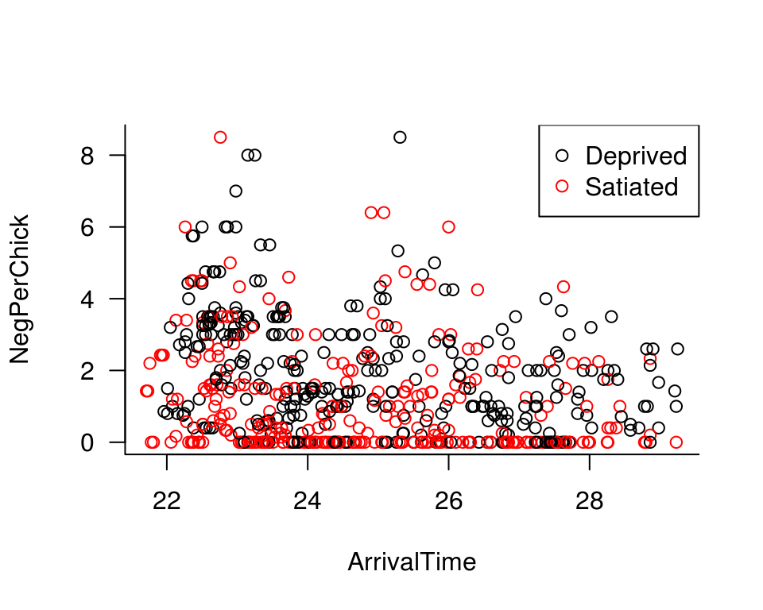

```r
owls <- read.table("data/Owls.txt",header=TRUE)
par(las=1,bty="l") ## cosmetic
plot(NegPerChick~ArrivalTime,col=FoodTreatment,data=owls)
legend("topright",pch=1,col=1:2,c("Deprived","Satiated"))
```

We also have information on brood size and parental sex, but we’ll save this for when we’re looking at data visualization …

Start by fitting a negative binomial model for the ratio of negotiation to brood size by adding an offset of `log(BroodSize)`. We’ll use arrival time, food treatment, and their interaction as predictors.

```r
glmnbfit <- glm.nb(SiblingNegotiation~ArrivalTime*FoodTreatment+
                   offset(log(BroodSize)),
               ## don't specify family (NB2 is assumed)
               data=owls)
```

Now we want to try fitting a zero-inflated model. In general, `pscl` models use a two-part model with the model for the ‘conditional’ part (i.e., the distribution of the values that are *not* sampling zeros) on the left side of the bar and the model for structural zeros or not on the right side of the bar. The first model we will fit uses the same model as before (arrival time, food treatment, and an offset for brood size) for the conditional distribution and an intercept-only model (`1`) for the structural zeros. In other words, we are going to assume there is a single rate of zero-inflation that applies to all observations regardless of arrival time or food treatment.

```r
ff <- SiblingNegotiation~ArrivalTime*FoodTreatment+offset(log(BroodSize))|1
glmzinbfit <- zeroinfl(ff,
                data=owls,
                dist="negbin")
```

A quick AIC check:

```r
AICtab(glmnbfit,glmzinbfit)
```

```
##            dAIC df
## glmzinbfit  0.0 6
## glmnbfit   65.7 5
```

This is a **huge** difference. *Compare the coefficients. What difference has zero-inflation made to the conclusions (use `summary()` to see $p$-values, etc.). Use `plogis()` (a handy version of the logistic function $1/(1+\exp(-x))$) to find the zero-inflation probability, which is stated on the logit scale.*

```r
cbind(NB=c(coef(glmnbfit),NA),
      ZINB=coef(glmzinbfit))
```

```
##                                            NB        ZINB
## (Intercept)                        4.05738935  3.66355741
## ArrivalTime                       -0.13861782 -0.11801655
## FoodTreatmentSatiated             -1.74333215 -2.21981350
## ArrivalTime:FoodTreatmentSatiated  0.04956159  0.08063301
##                                            NA -1.27858295
```

There’s a lot more to do here.

- Some preliminary investigation suggests that there might be some issues about the way we handle overdispersion. Our choices are (1) quasi-Poisson; (2) NB1, a negative binomial model with the same mean-variance relationship implied by QP; (3) NB2. `zeroinfl` doesn’t do QP or NB1, but we can use `glmmADMB` to fit a zero-inflated model as follows:

```r
glmzinb1fit <- glmmadmb(SiblingNegotiation~ArrivalTime*FoodTreatment+
                           offset(log(BroodSize)),
                       data=owls,family="nbinom1",zeroInflation=TRUE)
## family="nbinom" or family="nbinom2" gives an NB2 model
```

- Try `family="nbinom2` instead, and/or `zeroInflation=FALSE`, and use `AICtab` to compare the results. Compare the NB2 fits using `zeroinfl` and `glmmADMB`: are they the same?*
- Unfortunately, I don’t know of an easy graphical diagnostic for zero-inflation. For models with only categorical predictors, we can separate the data by categories (e.g. food treatment) and compare the distribution in each category to a Poisson distribution with the same mean. Comparing AICs or computing $p$-values is an OK way to test, but (1) it’s nice to be able to test the requirement for a more complex model without always having to fit it first and then see if it was needed; (2) graphical diagnostics often provide insights that we miss by just looking at the numbers.
- A good way to test models is to do *posterior predictive simulation*, i.e. generate simulations from the model and see how the distribution of some predicted value (in this case the total number of zeros) matches the observed value. If it’s available for a particular model type, the `simulate()` method makes this really easy:

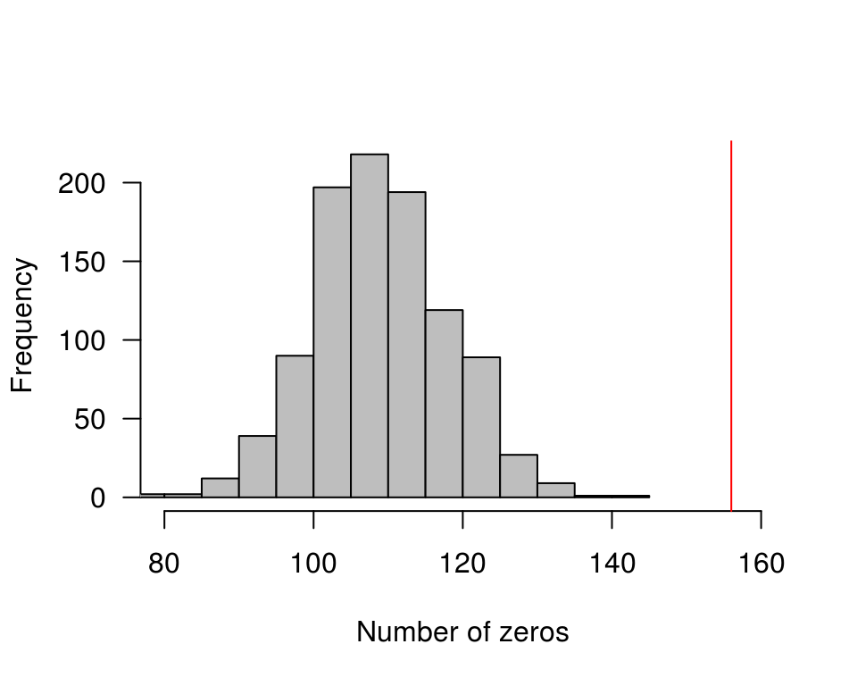

```r
par(las=1)
nbsim <- simulate(glmnbfit,1000)  ## each column is a simulation
predzeros <- colSums(nbsim==0)
hist(predzeros,col="gray",xlim=c(80,160),main="",
     xlab="Number of zeros")
## superimpose observed value
abline(v=sum(owls$SiblingNegotiation==0),col=2)
```

Unfortunately, `pscl` and `glmmADMB` don’t have `simulate()` methods … so we would have to do more work. * We could consider more complex zero-inflation models (i.e. putting more predictors on the right side of the bar in the `zeroinfl` model formula, e.g. `~...|ArrivalTime` to allow the amount of zero-inflation to depend on arrival time. * For more extended modeling of this data set see the [Owls project](https://groups.nceas.ucsb.edu/non-linear-modeling/projects/owls) from Bolker et al. (2013).

See also: [UCLA stats ZIP example](http://www.ats.ucla.edu/stat/r/dae/zipoisson.htm])

References

Bolker, Benjamin M., Beth Gardner, Mark Maunder, Casper W. Berg, Mollie Brooks, Liza Comita, Elizabeth Crone, et al. 2013. “Strategies for Fitting Nonlinear Ecological Models in R, AD Model Builder, and BUGS.” Edited by Satu Ramula. *Methods in Ecology and Evolution* 4 (6): 501–12. doi:10.1111/2041-210X.12044.

Roulin, Alexandre, and Louis-Felix Bersier. 2007. “Nestling Barn Owls Beg More Intensely in the Presence of Their Mother Than in the Presence of Their Father.” *Animal Behaviour* 74 (4): 1099–1106. doi:10.1016/j.anbehav.2007.01.027.